# Practical Machine Learning - Capstone Project

Sean Dobbs

6/6/2020

## Background, Purpose, and Data Preprocessing

Data for this project were generously made available from the following source:

*Ugulino, W.; Cardador, D.; Vega, K.; Velloso, E.; Milidiu, R.; Fuks, H. Wearable Computing: Accelerometers’ Data Classification of Body Postures and Movements. Proceedings of 21st Brazilian Symposium on Artificial Intelligence. Advances in Artificial Intelligence - SBIA 2012. In: Lecture Notes in Computer Science. , pp. 52-61. Curitiba, PR: Springer Berlin / Heidelberg, 2012. ISBN 978-3-642-34458-9. DOI: 10.1007/978-3-642-34459-6_6.*

*Read more: http://groupware.les.inf.puc-rio.br/har#ixzz*

Myriad readings from six(6) users executing dumbbell lifts, both correctly and incorrectly, were gathered from accelerometers mounted on the belt, forearm, arm, and the dumbbell itself. The data was split into a very large training set (over 19,000 rows - which will be partitioned and split further into a training and test set; 75% into the training set, and the remaining 25% into the testing set), and a small 20 row “testing” set (which will actually be used one by one to provide 20 individual predictions), and both were downloaded for use.

Additionally, there a large number of columns that serve to do nothing but mess up the prediction algorithms (timestamps, e.g) or have a massive majority of the entries being “NA” or NULL. So, those columns were removed from all of the data sets (see Appendix A for the code and columns removed):

The goal of this process is to use the information given in the training set to ascertain the fashion in which the exercise was done, given a set of predictors in the testing data set. The possible fashions in which the exercises were done are:

Class A: Exactly According To Specification  
Class B: Throwing Elbows To Front  
Class C: Lifting Dumbbell Only Halfway  
Class D: Lowering Dumbbell Only Halfway  
Class E: Throwing Hips To Front

In order to hopefully obtain the most accuracy, models will be fit, using three methods that are usually useful when the predicted outcome is categorical in nature and the data set is large, namely: Trees, Random Forest, and Logistic Regression (specifically, Multinomial Logistic Regression). Then the models, if reasonably accurate (but none are overwhelmingly accurate on their own) will be stacked to potentially increase accuracy further.

## RPART (Trees) Model Building and Analysis

The first model was fit using the RPART (Trees) method:

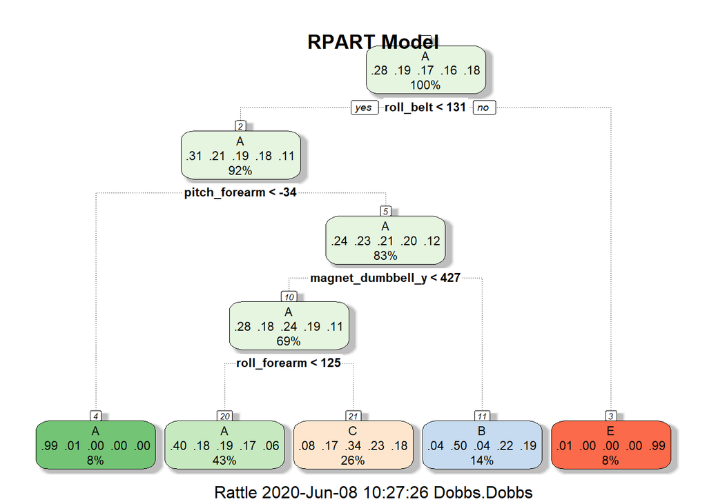

*RPART Method Confusion Matrix Overview*

```
##           Reference
## Prediction    A    B    C    D    E
##          A 1272   36   83    0    4
##          B  387  321  241    0    0
##          C  385   37  433    0    0
##          D  348  154  302    0    0
##          E  128  135  242    0  396
```

```
##       Accuracy          Kappa  AccuracyLower  AccuracyUpper   AccuracyNull
##      0.4938825      0.3389563      0.4797948      0.5079776      0.5138662
## AccuracyPValue  McnemarPValue
##      0.9975508            NaN
```

*Distribution of Actual Classes From Training Data Set*

```
##    A    B    C    D    E
## 4185 2848 2567 2412 2706
```

## Random Forest Model Building and Analysis

The second model was fit using the Random Forest method:

*note: 20 trees was also tried; accuracy increased infinitesimally, but processing time (which was already a couple minutes) increased exponentially.*

*Random Forest Method Confusion Matrix Overview*

```
##           Reference
## Prediction    A    B    C    D    E
##          A 1395    0    0    0    0
##          B    3  945    1    0    0
##          C    0   10  845    0    0
##          D    0    0    5  798    1
##          E    0    0    0    2  899
```

```
##       Accuracy          Kappa  AccuracyLower  AccuracyUpper   AccuracyNull
##      0.9955139      0.9943250      0.9932158      0.9971865      0.2850734
## AccuracyPValue  McnemarPValue
##      0.0000000            NaN
```

```
## Random Forest
##
## 14718 samples
##    55 predictor
##     5 classes: 'A', 'B', 'C', 'D', 'E'
##
## No pre-processing
## Resampling: Cross-Validated (10 fold)
## Summary of sample sizes: 13245, 13246, 13245, 13248, 13247, 13247, ...
## Resampling results across tuning parameters:
##
##   mtry  Accuracy   Kappa
##    2    0.9818584  0.9770451
##   30    0.9949042  0.9935542
##   59    0.9926616  0.9907171
##
## Accuracy was used to select the optimal model using the largest value.
## The final value used for the model was mtry = 30.
```

Indeed, the accuracy of the Random Forest method for this data set is validated.

## Multinomial Logistic Regression Method Building and Analysis

The third and final model was fit using the Multinomial Logistic Regression method. BoxCox preprocessing was added to the model training, as, unlike with the Tree/Forest methods, Logistic Regression models seldom do well without preprocessing:

*Multinomial Logistic Regression Method Confusion Matrix Overview*

```
##           Reference
## Prediction    A    B    C    D    E
##          A 1193   68   47   57   30
##          B  163  498  157   34   97
##          C  113  101  498   66   77
##          D   87   58  115  519   25
##          E   95  115   52  109  530
```

```
##       Accuracy          Kappa  AccuracyLower  AccuracyUpper   AccuracyNull
##   6.602773e-01   5.675136e-01   6.468274e-01   6.735362e-01   3.366639e-01
## AccuracyPValue  McnemarPValue
##   0.000000e+00   6.634469e-37
```

The Multivariate Logistic Regression method is 66% accurate. Not bad, surely, but nowhere near the accuracy seen with the Random Forest method. Another cross-validation method, a repeated k-Fold Cross Validation, was executed on the Multinomial Logistic Regression fit:

```
## Penalized Multinomial Regression
##
## 14718 samples
##    55 predictor
##     5 classes: 'A', 'B', 'C', 'D', 'E'
##
## No pre-processing
## Resampling: Cross-Validated (10 fold, repeated 3 times)
## Summary of sample sizes: 13245, 13246, 13247, 13246, 13248, 13245, ...
## Resampling results across tuning parameters:
##
##   decay  Accuracy   Kappa
##   0e+00  0.6709688  0.5821479
##   1e-04  0.6709688  0.5821479
##   1e-01  0.6709688  0.5821479
##
## Accuracy was used to select the optimal model using the largest value.
## The final value used for the model was decay = 0.1.
```

A similar 67% accuracy for the true identification of the “classe” variable emerges.

## Conclusion

Among the methods considered, the Random Forest method is hands-down the most accurate. Additionally, for this data set, the Random Forest method was extraordinarily accurate. Thus, no model stacking was considered, and the Random Forest method alone was chosen as the best predictor for this data set.

## Appendix

1. Data cleaning detail

PMLtrain <- select(PMLtrain, -c(“var_roll_arm”, “avg_pitch_arm”, “stddev_pitch_arm”, “var_pitch_arm”, “avg_yaw_arm”, “stddev_yaw_arm”, “var_yaw_arm”, “kurtosis_roll_arm”, “kurtosis_picth_arm”, “kurtosis_yaw_arm”, “skewness_roll_arm”, “skewness_pitch_arm”, “skewness_yaw_arm”, “max_roll_arm”, “max_picth_arm”, “max_yaw_arm”, “min_roll_arm”, “min_pitch_arm”, “min_yaw_arm”, “amplitude_roll_arm”, “amplitude_pitch_arm”, “amplitude_yaw_arm”, “kurtosis_roll_dumbbell”, “kurtosis_picth_dumbbell”, “kurtosis_yaw_dumbbell”, “skewness_roll_dumbbell”, “skewness_pitch_dumbbell”, “skewness_yaw_dumbbell”, “max_roll_dumbbell”, “max_picth_dumbbell”, “max_yaw_dumbbell”, “min_roll_dumbbell”, “min_pitch_dumbbell”, “min_yaw_dumbbell”, “amplitude_roll_dumbbell”, “amplitude_pitch_dumbbell”, “amplitude_yaw_dumbbell”, “var_accel_dumbbell”, “avg_roll_dumbbell”, “stddev_roll_dumbbell”, “var_roll_dumbbell”, “avg_pitch_dumbbell”, “stddev_pitch_dumbbell”, “var_pitch_dumbbell”, “avg_yaw_dumbbell”, “stddev_yaw_dumbbell”, “var_yaw_dumbbell”, “kurtosis_roll_forearm”, “kurtosis_picth_forearm”, “kurtosis_yaw_forearm”, “skewness_roll_forearm”, “skewness_pitch_forearm”, “skewness_yaw_forearm”, “max_roll_forearm”, “max_picth_forearm”, “max_yaw_forearm”, “min_roll_forearm”, “min_pitch_forearm”, “min_yaw_forearm”, “amplitude_roll_forearm”, “amplitude_pitch_forearm”, “amplitude_yaw_forearm”, “var_accel_forearm”, “avg_roll_forearm”, “stddev_roll_forearm”, “var_roll_forearm”, “avg_pitch_forearm”, “stddev_pitch_forearm”, “var_pitch_forearm”, “avg_yaw_forearm”, “stddev_yaw_forearm”, “var_yaw_forearm”, “kurtosis_picth_belt”, “kurtosis_yaw_belt”, “skewness_roll_belt”, “skewness_roll_belt.1”, “skewness_yaw_belt”, “max_roll_belt”, “max_picth_belt”, “max_yaw_belt”, “min_roll_belt”, “min_pitch_belt”, “min_yaw_belt”, “amplitude_roll_belt”, “amplitude_pitch_belt”, “amplitude_yaw_belt”, “var_total_accel_belt”, “avg_roll_belt”, “stddev_roll_belt”, “var_roll_belt”, “avg_pitch_belt”, “stddev_pitch_belt”, “var_pitch_belt”, “avg_yaw_belt”, “stddev_yaw_belt”, “var_yaw_belt”, “var_accel_arm”, “avg_roll_arm”, “stddev_roll_arm”, “kurtosis_picth_belt”, “kurtosis_yaw_belt”, “skewness_roll_belt”, “skewness_roll_belt.1”, “skewness_yaw_belt”, “max_roll_belt”, “max_picth_belt”, “max_yaw_belt”, “min_roll_belt”, “min_pitch_belt”, “min_yaw_belt”, “amplitude_roll_belt”, “amplitude_pitch_belt”, “amplitude_yaw_belt”, “var_total_accel_belt”, “avg_roll_belt”, “stddev_roll_belt”, “var_roll_belt”, “avg_pitch_belt”, “stddev_pitch_belt”, “var_pitch_belt”, “avg_yaw_belt”, “stddev_yaw_belt”, “var_yaw_belt”, “var_accel_arm”, “avg_roll_arm”, “stddev_roll_arm”, “kurtosis_roll_belt”, “raw_timestamp_part_1”,“raw_timestamp_part_2”,“cvtd_timestamp”))

PMLquizcases <- select(PMLquizcases, -c(“var_roll_arm”, “avg_pitch_arm”, “stddev_pitch_arm”, “var_pitch_arm”, “avg_yaw_arm”, “stddev_yaw_arm”, “var_yaw_arm”, “kurtosis_roll_arm”, “kurtosis_picth_arm”, “kurtosis_yaw_arm”, “skewness_roll_arm”, “skewness_pitch_arm”, “skewness_yaw_arm”, “max_roll_arm”, “max_picth_arm”, “max_yaw_arm”, “min_roll_arm”, “min_pitch_arm”, “min_yaw_arm”, “amplitude_roll_arm”, “amplitude_pitch_arm”, “amplitude_yaw_arm”, “kurtosis_roll_dumbbell”, “kurtosis_picth_dumbbell”, “kurtosis_yaw_dumbbell”, “skewness_roll_dumbbell”, “skewness_pitch_dumbbell”, “skewness_yaw_dumbbell”, “max_roll_dumbbell”, “max_picth_dumbbell”, “max_yaw_dumbbell”, “min_roll_dumbbell”, “min_pitch_dumbbell”, “min_yaw_dumbbell”, “amplitude_roll_dumbbell”, “amplitude_pitch_dumbbell”, “amplitude_yaw_dumbbell”, “var_accel_dumbbell”, “avg_roll_dumbbell”, “stddev_roll_dumbbell”, “var_roll_dumbbell”, “avg_pitch_dumbbell”, “stddev_pitch_dumbbell”, “var_pitch_dumbbell”, “avg_yaw_dumbbell”, “stddev_yaw_dumbbell”, “var_yaw_dumbbell”, “kurtosis_roll_forearm”, “kurtosis_picth_forearm”, “kurtosis_yaw_forearm”, “skewness_roll_forearm”, “skewness_pitch_forearm”, “skewness_yaw_forearm”, “max_roll_forearm”, “max_picth_forearm”, “max_yaw_forearm”, “min_roll_forearm”, “min_pitch_forearm”, “min_yaw_forearm”, “amplitude_roll_forearm”, “amplitude_pitch_forearm”, “amplitude_yaw_forearm”, “var_accel_forearm”, “avg_roll_forearm”, “stddev_roll_forearm”, “var_roll_forearm”, “avg_pitch_forearm”, “stddev_pitch_forearm”, “var_pitch_forearm”, “avg_yaw_forearm”, “stddev_yaw_forearm”, “var_yaw_forearm”, “kurtosis_picth_belt”, “kurtosis_yaw_belt”, “skewness_roll_belt”, “skewness_roll_belt.1”, “skewness_yaw_belt”, “max_roll_belt”, “max_picth_belt”, “max_yaw_belt”, “min_roll_belt”, “min_pitch_belt”, “min_yaw_belt”, “amplitude_roll_belt”, “amplitude_pitch_belt”, “amplitude_yaw_belt”, “var_total_accel_belt”, “avg_roll_belt”, “stddev_roll_belt”, “var_roll_belt”, “avg_pitch_belt”, “stddev_pitch_belt”, “var_pitch_belt”, “avg_yaw_belt”, “stddev_yaw_belt”, “var_yaw_belt”, “var_accel_arm”, “avg_roll_arm”, “stddev_roll_arm”, “kurtosis_picth_belt”, “kurtosis_yaw_belt”, “skewness_roll_belt”, “skewness_roll_belt.1”, “skewness_yaw_belt”, “max_roll_belt”, “max_picth_belt”, “max_yaw_belt”, “min_roll_belt”, “min_pitch_belt”, “min_yaw_belt”, “amplitude_roll_belt”, “amplitude_pitch_belt”, “amplitude_yaw_belt”, “var_total_accel_belt”, “avg_roll_belt”, “stddev_roll_belt”, “var_roll_belt”, “avg_pitch_belt”, “stddev_pitch_belt”, “var_pitch_belt”, “avg_yaw_belt”, “stddev_yaw_belt”, “var_yaw_belt”, “var_accel_arm”, “avg_roll_arm”, “stddev_roll_arm”, “kurtosis_roll_belt”, “raw_timestamp_part_1”,“raw_timestamp_part_2”,“cvtd_timestamp”))